| title: “Reproducible Research - Assessment 1” |
| --- |
| author: “José Miguel Reséndiz” |
| date: “Tuesday, February 10, 2015” |
| output: html_document |

## INTRODUCCTION

It is now possible to collect a large amount of data about personal movement using activity monitoring devices such as a [Fitbit](http://www.fitbit.com/mx), [Nike Fuelband](http://www.nike.com/us/en_us/c/nikeplus-fuelband), or [Jawbone Up](https://jawbone.com/intl/up). These type of devices are part of the “quantified self” movement - a group of enthusiasts who take measurements about themselves regularly to improve their health, to find patterns in their behavior, or because they are tech geeks. But these data remain under-utilized both because the raw data are hard to obtain and there is a lack of statistical methods and software for processing and interpreting the data.

## Data

The data for this assignment can be downloaded from the course web site:

Dataset: [Activity monitoring data [52K]](https://d396qusza40orc.cloudfront.net/repdata%2Fdata%2Factivity.zip)

The variables included in this dataset are:

**steps:** Number of steps taking in a 5-minute interval (missing values are coded as NA)

**date:** The date on which the measurement was taken in YYYY-MM-DD format

**interval:** Identifier for the 5-minute interval in which measurement was taken

The dataset is stored in a comma-separated-value (CSV) file and there are a total of 17,568 observations in this dataset.

### LOADING AND PROCESSING THE DATA

Load Data

```r
dataPerMov<-read.csv("activity.csv")
```

Raw Data

```
##   steps       date interval
## 1    NA 2012-10-01        0
## 2    NA 2012-10-01        5
## 3    NA 2012-10-01       10
## 4    NA 2012-10-01       15
## 5    NA 2012-10-01       20
## 6    NA 2012-10-01       25
```

Structure

```
## 'data.frame':    17568 obs. of  3 variables:
##  $ steps   : int  NA NA NA NA NA NA NA NA NA NA ...
##  $ date    : Factor w/ 61 levels "2012-10-01","2012-10-02",..: 1 1 1 1 1 1 1 1 1 1 ...
##  $ interval: int  0 5 10 15 20 25 30 35 40 45 ...
```

Select only the rows with values different of NA.

```r
library(stringr)
dataPerMov<-read.csv("activity.csv")
dataPerMov<-na.omit(dataPerMov)
dataPerMov <- data.frame(date = dataPerMov$date,  interval = dataPerMov$interval, steps = dataPerMov$steps)
head(dataPerMov)
```

```
##         date interval steps
## 1 2012-10-02        0     0
## 2 2012-10-02        5     0
## 3 2012-10-02       10     0
## 4 2012-10-02       15     0
## 5 2012-10-02       20     0
## 6 2012-10-02       25     0
```

### What is mean total number of steps taken per day?

Histogram of the total number of steps taken each day

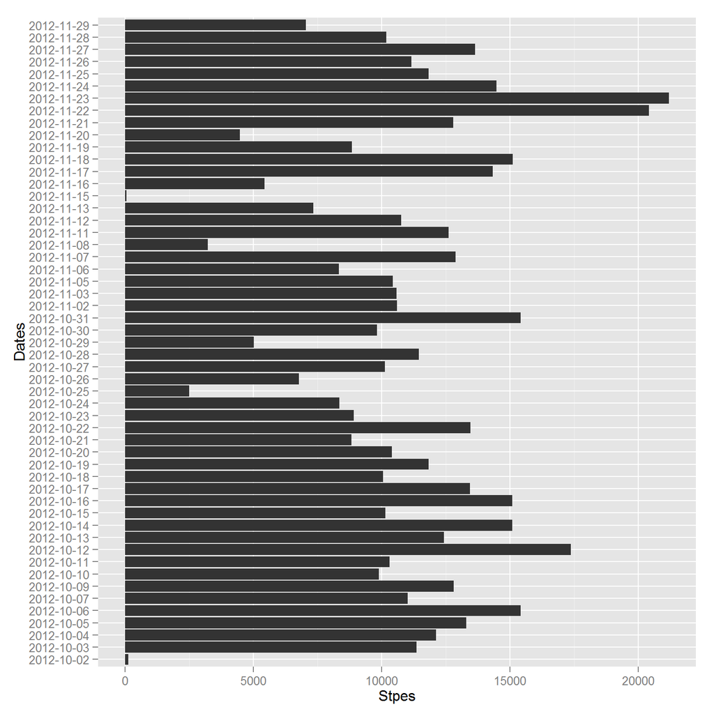

Mean and median total number of steps taken per day

```
##          DATE  MEAN_STEP MEDIAN_STEP
## 1  2012-10-02  0.4375000           0
## 2  2012-10-03 39.4166667           0
## 3  2012-10-04 42.0694444           0
## 4  2012-10-05 46.1597222           0
## 5  2012-10-06 53.5416667           0
## 6  2012-10-07 38.2465278           0
## 7  2012-10-09 44.4826389           0
## 8  2012-10-10 34.3750000           0
## 9  2012-10-11 35.7777778           0
## 10 2012-10-12 60.3541667           0
## 11 2012-10-13 43.1458333           0
## 12 2012-10-14 52.4236111           0
## 13 2012-10-15 35.2048611           0
## 14 2012-10-16 52.3750000           0
```

[output cut: 39 more lines]

### What is the average daily activity pattern?

Series of the 5-minute interval (x-axis) and the average number of steps taken, averaged across all days (y-axis)

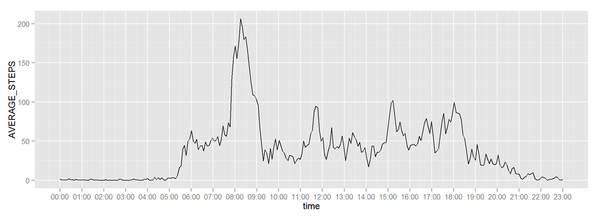

Which 5-minute interval, on average across all the days in the dataset, contains the maximum number of steps?

```
##     INTERVAL MEAN_STEP
## 104      835  206.1698
```

### IMPUTING MISSING VALUES

Number of NA rows

```r
dataPerMov<-read.csv("activity.csv")
nrow(dataPerMov[is.na(dataPerMov$steps),])
```

```
## [1] 2304
```

Filling in all of the missing values in the dataset.We use the mean for that day and 5-minute interval

```r
#Prepare Data
dataPerMovRaw<-read.csv("activity.csv")
auxData <- cbind(dataPerMovRaw,wday = as.POSIXlt(dataPerMovRaw$date)$wday)
dataPerMov<-auxData[!is.na(auxData$steps),]
dataPerMovNA <-auxData[is.na(auxData$steps),]

#Calculating of mean by interval and week day for the values NA
dataPerMovMean<- aggregate(dataPerMov$steps, by=list(interval=dataPerMov$interval, wday=dataPerMov$wday), FUN=mean)
names(dataPerMovMean) <- c("interval","wday","mean")

#Building final data set
tempAux <- merge(dataPerMovNA,dataPerMovMean)
dataPerMovNA <- data.frame(steps = tempAux$mean, date = tempAux$date, interval = tempAux$interval, wday = tempAux$wday)
finalDataSet <- rbind(dataPerMovNA,dataPerMov)
head(finalDataSet)
```

```
##      steps       date interval wday
## 1 0.000000 2012-11-04        0    0
## 2 1.428571 2012-10-01        0    1
## 3 1.428571 2012-10-08        0    1
## 4 4.250000 2012-11-14        0    3
## 5 5.875000 2012-11-01        0    4
## 6 0.000000 2012-11-09        0    5
```

Output

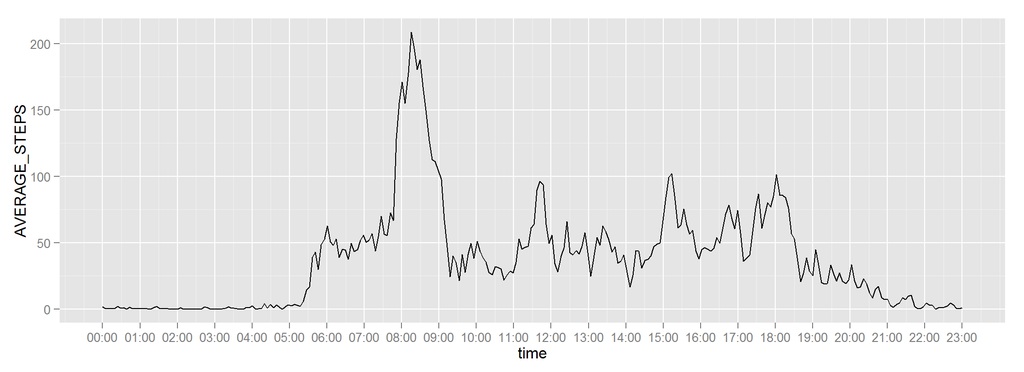

### Mean and median total number of steps taken per day

```
##          DATE  MEAN_STEP MEDIAN_STEP
## 1  2012-10-01 34.6349206    8.214286
## 2  2012-10-02  0.4375000    0.000000
## 3  2012-10-03 39.4166667    0.000000
## 4  2012-10-04 42.0694444    0.000000
## 5  2012-10-05 46.1597222    0.000000
## 6  2012-10-06 53.5416667    0.000000
## 7  2012-10-07 38.2465278    0.000000
## 8  2012-10-08 34.6349206    8.214286
## 9  2012-10-09 44.4826389    0.000000
## 10 2012-10-10 34.3750000    0.000000
## 11 2012-10-11 35.7777778    0.000000
## 12 2012-10-12 60.3541667    0.000000
## 13 2012-10-13 43.1458333    0.000000
## 14 2012-10-14 52.4236111    0.000000
```

[output cut: 47 more lines]

### Do these values differ from the estimates from the first part of the assignment?

```
##          DATE MEAN_STEP_NA MEDIAN_STEP_NA  MEAN_STEP MEDIAN_STEP
## 1  2012-10-02    0.4375000              0  0.4375000           0
## 2  2012-10-03   39.4166667              0 39.4166667           0
## 3  2012-10-04   42.0694444              0 42.0694444           0
## 4  2012-10-05   46.1597222              0 46.1597222           0
## 5  2012-10-06   53.5416667              0 53.5416667           0
## 6  2012-10-07   38.2465278              0 38.2465278           0
## 7  2012-10-09   44.4826389              0 44.4826389           0
## 8  2012-10-10   34.3750000              0 34.3750000           0
## 9  2012-10-11   35.7777778              0 35.7777778           0
## 10 2012-10-12   60.3541667              0 60.3541667           0
## 11 2012-10-13   43.1458333              0 43.1458333           0
## 12 2012-10-14   52.4236111              0 52.4236111           0
## 13 2012-10-15   35.2048611              0 35.2048611           0
## 14 2012-10-16   52.3750000              0 52.3750000           0
```

[output cut: 39 more lines]

#### What is the impact of imputing missing data on the estimates of the total daily number of steps?

There´re some rows with any value, but this reason, we cant’t calculat a value.

```
##          DATE MEAN_STEP_NA MEDIAN_STEP_NA MEAN_STEP MEDIAN_STEP
## 1  2012-10-01     34.63492       8.214286        NA          NA
## 8  2012-10-08     34.63492       8.214286        NA          NA
## 32 2012-11-01     28.51649       7.750000        NA          NA
## 35 2012-11-04     42.63095      23.857143        NA          NA
## 40 2012-11-09     42.91567      15.500000        NA          NA
## 41 2012-11-10     43.52579      16.428571        NA          NA
## 45 2012-11-14     40.94010      12.625000        NA          NA
## 61 2012-11-30     42.91567      15.500000        NA          NA
```

#### Are there differences in activity patterns between weekdays and weekends?

Create a new factor variable in the dataset with two levels - “weekday” and “weekend” indicating whether a given date is a weekday or weekend day

```
##       steps       date interval    wday
## 1  0.000000 2012-11-04        0 weekend
## 2  1.428571 2012-10-01        0 weekday
## 3  1.428571 2012-10-08        0 weekday
## 4  4.250000 2012-11-14        0 weekday
## 5  5.875000 2012-11-01        0 weekday
## 6  0.000000 2012-11-09        0 weekday
## 7  0.000000 2012-11-30        0 weekday
## 8  0.000000 2012-11-10        0 weekend
## 9  0.000000 2012-11-04       10 weekend
## 10 0.000000 2012-10-08       10 weekday
```

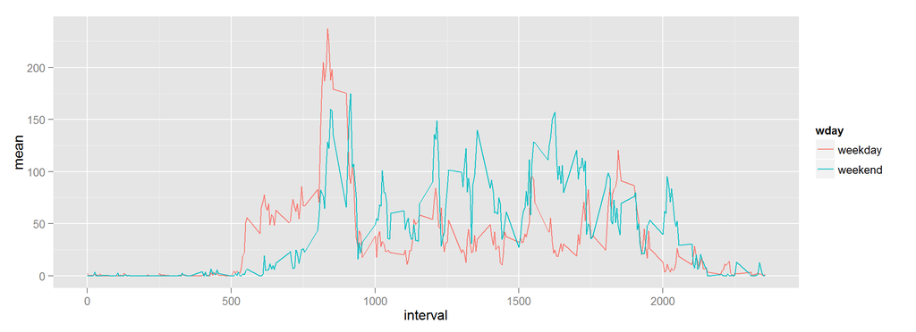